# **Spatial Autocorrelation of Hyperscale Data Centers and Their Community Impacts in the United States**

**Author:** Shanmukh Upadhyayula

**Date:** 15 May 2026

## Introduction

The rapid expansion of artificial intelligence is driving the construction of many hyperscale data centers across the United States, with their main purpose being for training AI models. These data centers are not highly clustered across the entire country, but are situated across many small hot spots. With the increasing rate of construction of hyperscale data centers, there is also an increase in protests against such data centers being created, as many people believe that the host counties of data centers face increasing housing costs, increasing electricity bills, droughts caused by data center water usage, poor air quality, and increasing electricity demand.

The motivation for this project is to attempt to answer whether these host counties are even facing such problems, if those are spatially clustered, and if there are positive or negative associations with each of these problems and hyperscale data center density. The justification for wanting to find spatial clustering and associations is that data center density is a spatial problem. Looking at raw counts or non-spatial data excludes a dimension that won't satisfy questions of whether there is clustering or associations.

The hypothesis below details the expectation, but most of these problems are not expected to be strongly tied to data center density, with the exception of electricity demand growth because that is a requirement for data centers, rather than what is seen as a side-effect. Spatial dependence and spatial heterogeneity will both be trends of interest. Spatial dependence is a trend of interest because knowing whether data center host counties share similar community impacts to their neighbors is a core part of answering the research question below. Spatial heterogeneity is a trend of interest because the distribution of data centers across the United States is very sparse, as revealed in the pre-cursor analysis to this project. Any associations with data centers and community impacts can vary greatly from region to region. For example, hot spots in Texas counties can be completely different from hot spots in Virginia. Bias is also a concern for this project. The spatial autocorrelation and spatial regression tests may reveal something completely different than the actual community impacts. This is due in part to the limitations of open source datasets available online and the data generating process. Additionally, county-level aggregation introduces the modifiable areal unit problem. One example of this problem in this project arises in the electricity demand choropleth & LISA maps. Since only state-wide data is publicly available as of May 2026, the granularity is not small enough to see truly accurate results. This is also the case for a county-level analysis as well, but aggregating to a smaller level would make map displays impractical, especially since there are approximately 85,000 census tracts in the United States. Therefore, the results should be seen as descriptive of spatial patterns rather than data center causal impacts on communities.

**Research Question:** Does hyperscale data center density exhibit statistically significant spatial clustering and spatial association with home value appreciation, electricity price growth, drought stress, air quality degradation, and electricity demand growth?

**Hypothesis:** Hyperscale data center density has almost no associations and little clustering with residential housing price appreciation, electricity price growth, drought stress, and air quality degradation at the U.S. county scale, but has a strong positive association and clustering with electricity demand growth.

## Methods

There are five parts to this project's data analysis. First, data centers are filtered to a new gdf for just hyperscale data centers. This is because it is difficult to find an exact dataset for AI data centers online, but hyperscale data centers encompass AI data centers. These hyperscale data centers are managed by large companies. Next, the raw datasets are aggregated to US county polygons, except for electricity demand because the Energy Information Administration only reports this variable at a balancing authority level. These balancing authorities have grid topologies that don't align with county boundaries. Once the datasets are aggregated, descriptive statistics and choropleth maps are used to characterize the geographic distribution of hyperscale data center density and each community impact variable. Then, bivariate spatial autocorrelation Moran's I and LISA tests are performed to look for spatial dependence. A multivariate test with all variables is also performed. Finally, spatial regression models are applied to assess the degree to which data centers statistically associate with each community impact variable to look for spatial heterogeneity.

### Data

The analysis uses twelve datasets: county & state boundaries (USCB 2024, 2025), global data center locations (ATLAS 2025), home price appreciation (Zillow 2026), electricity rates (Energy Information Administration 2026), county population (USCB 2023), air quality index (Environmental Protection Agency 2025), drought severity (National Drought Mitigation Center, U.S. Department of Agriculture, and National Oceanic and Atmospheric Administration 2026), and electricity demand balance & subregion (Energy Information Administration 2022, 2026). Details on dataset retrieval locations can be seen in the references section.

Hyperscale data center locations are determined by if their company column is one of the major AI companies: Amazon, Microsoft, Google, Meta, Oracle, Apple, IBM, SoftLayer, Applied Digital, Anthropic, Fluidstack, xAI, CoreWeave, Crusoe, and Nebius. OpenAI is probably the most major AI company, but does not manufacture data centers of its own.

Most of the date ranges are from 2022 to 2026, as 2022 was the year where AI Data Centers became the most prevalent. This gives a big enough change from a time before the popularity of AI and the present day.

| File | Source | Most recent | Granularity |
| --- | --- | --- | --- |
| `counties.geojson` | TIGER/Census | static | 3,220 county polygons |
| `state_boundaries/tl_2025_us_state.shp` | [TIGER/Census 2025](https://www.census.gov/geographies/mapping-files/time-series/geo/tiger-line-file.html) | 2025 | 50 state + DC polygons |
| `datacenters.geojson` | ATLAS | 2024-2025 | 2,968 U.S. point facilities |
| `ZHVI.csv` | [Zillow ZHVI](https://www.zillow.com/research/data/) | 2026-03 | county home-value index, monthly |
| `electricity_rates` | Energy Information Administration | Feb 2022, Feb 2026 | congressional district utility prices, monthly |
| `county_population_2023.csv` | [Census ACS](https://www.census.gov/data/developers/data-sets/acs-5year.html) | 2019-2023 | county population |
| `annual_aqi_by_county_2025.csv` | [EPA AQS](https://www.epa.gov/outdoor-air-quality-data) | 2025 | county PM2.5 air quality days, annual |
| `drought.csv` | [U.S. Drought Monitor](https://droughtmonitor.unl.edu/DmData/DataDownload/ComprehensiveStatistics.aspx) | 2022-2026 | county weekly drought severity |
| `EIA930_BALANCE_2022_Jan_Jun.csv`, `EIA930_BALANCE_2026_Jan_Jun.csv` | [Hourly Electric Grid Monitor (U.S. EIA)](https://www.eia.gov/electricity/gridmonitor/) | Feb 2022, Feb 2026 | hourly demand per balancing authority, two years |
| `EIA930_SUBREGION_2022_Jan_Jun.csv`, `EIA930_SUBREGION_2026_Jan_Jun.csv` | [Hourly Electric Grid Monitor (U.S. EIA)](https://www.eia.gov/electricity/gridmonitor/) | Feb 2022, Feb 2026 | hourly demand per RTO subregion (e.g. PJM-DOM, Dominion), two years |

#### Imports

```python
import json
import os
import re
import warnings
warnings.filterwarnings("ignore")

import geopandas as gpd
import mapclassify
import matplotlib.pyplot as plt
import numpy as np
import pandas as pd
import plotly.express as px
import plotly.graph_objects as go
import plotly.io as pio
import requests
import spreg
from esda.moran import Moran_BV, Moran_Local_BV
from IPython.display import display
from libpysal import weights
from splot.esda import moran_scatterplot
from scipy.stats import norm

# This used to be a separate file, in order to avoid clutter, but Canvas only allows one file upload per submission.
STATE_ABBREV_TO_NAME = {
    'AL': 'Alabama',       'AK': 'Alaska',        'AZ': 'Arizona',       'AR': 'Arkansas',
    'CA': 'California',    'CO': 'Colorado',       'CT': 'Connecticut',   'DE': 'Delaware',
    'DC': 'District of Columbia', 'FL': 'Florida', 'GA': 'Georgia',       'HI': 'Hawaii',
    'ID': 'Idaho',         'IL': 'Illinois',       'IN': 'Indiana',       'IA': 'Iowa',
    'KS': 'Kansas',        'KY': 'Kentucky',       'LA': 'Louisiana',     'ME': 'Maine',
    'MD': 'Maryland',      'MA': 'Massachusetts',  'MI': 'Michigan',      'MN': 'Minnesota',
    'MS': 'Mississippi',   'MO': 'Missouri',       'MT': 'Montana',       'NE': 'Nebraska',
    'NV': 'Nevada',        'NH': 'New Hampshire',  'NJ': 'New Jersey',    'NM': 'New Mexico',
    'NY': 'New York',      'NC': 'North Carolina', 'ND': 'North Dakota',  'OH': 'Ohio',
    'OK': 'Oklahoma',      'OR': 'Oregon',         'PA': 'Pennsylvania',  'RI': 'Rhode Island',
    'SC': 'South Carolina','SD': 'South Dakota',   'TN': 'Tennessee',     'TX': 'Texas',
    'UT': 'Utah',          'VT': 'Vermont',        'VA': 'Virginia',      'WA': 'Washington',
    'WV': 'West Virginia', 'WI': 'Wisconsin',      'WY': 'Wyoming',
}
STATE_ABBREVS = list(STATE_ABBREV_TO_NAME)
STATE_NAME_TO_FIPS = {
    'Alabama': '01', 'Alaska': '02', 'Arizona': '04', 'Arkansas': '05', 'California': '06',
    'Colorado': '08', 'Connecticut': '09', 'Delaware': '10', 'District Of Columbia': '11',
    'Florida': '12', 'Georgia': '13', 'Hawaii': '15', 'Idaho': '16', 'Illinois': '17',
    'Indiana': '18', 'Iowa': '19', 'Kansas': '20', 'Kentucky': '21', 'Louisiana': '22',
    'Maine': '23', 'Maryland': '24', 'Massachusetts': '25', 'Michigan': '26', 'Minnesota': '27',
    'Mississippi': '28', 'Missouri': '29', 'Montana': '30', 'Nebraska': '31', 'Nevada': '32',
    'New Hampshire': '33', 'New Jersey': '34', 'New Mexico': '35', 'New York': '36',
    'North Carolina': '37', 'North Dakota': '38', 'Ohio': '39', 'Oklahoma': '40', 'Oregon': '41',
    'Pennsylvania': '42', 'Rhode Island': '44', 'South Carolina': '45', 'South Dakota': '46',
    'Tennessee': '47', 'Texas': '48', 'Utah': '49', 'Vermont': '50', 'Virginia': '51',
    'Washington': '53', 'West Virginia': '54', 'Wisconsin': '55', 'Wyoming': '56',
}
STATE_FIPS_TO_ABBREV = {
    '01': 'AL', '02': 'AK', '04': 'AZ', '05': 'AR', '06': 'CA', '08': 'CO', '09': 'CT',
    '10': 'DE', '11': 'DC', '12': 'FL', '13': 'GA', '15': 'HI', '16': 'ID', '17': 'IL',
    '18': 'IN', '19': 'IA', '20': 'KS', '21': 'KY', '22': 'LA', '23': 'ME', '24': 'MD',
    '25': 'MA', '26': 'MI', '27': 'MN', '28': 'MS', '29': 'MO', '30': 'MT', '31': 'NE',
    '32': 'NV', '33': 'NH', '34': 'NJ', '35': 'NM', '36': 'NY', '37': 'NC', '38': 'ND',
    '39': 'OH', '40': 'OK', '41': 'OR', '42': 'PA', '44': 'RI', '45': 'SC', '46': 'SD',
    '47': 'TN', '48': 'TX', '49': 'UT', '50': 'VT', '51': 'VA', '53': 'WA', '54': 'WV',
    '55': 'WI', '56': 'WY',
}
STATE_FIPS_TO_NAME = {fips: STATE_ABBREV_TO_NAME[abbrev] for fips, abbrev in STATE_FIPS_TO_ABBREV.items()}
BA_TO_STATEFP = {
    "AECI":"29","AVA":"53","AVRN":"41","AZPS":"04","BANC":"06","BHBA":"46",
    "BPAT":"41","CHPD":"53","CISO":"06","CPLE":"37","CPLW":"37","DEAA":"04",
    "DOPD":"53","DUK":"37","EPE":"48","ERCO":"48","FMPP":"12","FPC":"12",
    "FPL":"12","GCPD":"53","GVL":"12","GWA":"30","HGMA":"04","HST":"12",
    "IID":"06","IPCO":"16","ISNE":"25","JEA":"12","LDWP":"06","LGEE":"21",
    "MISO":"27","NEVP":"32","NSB":"12","NWMT":"30","NYIS":"36","OVEC":"39",
    "PACE":"49","PACW":"41","PGE":"41","PJM":"42","PNM":"35","PSCO":"08",
    "PSEI":"53","SC":"45","SCEG":"45","SCL":"53","SEC":"12","SEPA":"13",
    "SOCO":"13","SPA":"05","SRP":"04","SWPP":"20","TAL":"12","TEC":"12",
    "TEPC":"04","TIDC":"06","TPWR":"53","TVA":"47","WACM":"08","WALC":"04",
    "WAUW":"30","WWA":"53","YAD":"37",
}
PJM_SUBREGION_TO_STATEFP = {
    "AE":"34","AEP":"39","AP":"54","ATSI":"39","BC":"24","CE":"17","DAY":"39",
    "DEOK":"39","DOM":"51","DPL":"10","DUQ":"42","EKPC":"21","JC":"34","ME":"42",
    "PE":"42","PEP":"11","PL":"42","PN":"42","PS":"34","RECO":"34",
}

# === Inlined from map_utils.py ===
MAP_STYLE  = "carto-positron"
MAP_CENTER = {"lat": 39.5, "lon": -98.5}
MAP_ZOOM   = 3.2
MAP_HEIGHT = 600

state_borders = gpd.read_file(
    "../Data/data_center_analysis/state_boundaries/tl_2025_us_state.shp"
).to_crs("EPSG:4326")
state_borders = state_borders[state_borders["STUSPS"].isin(STATE_ABBREVS)]
state_borders["geometry"] = state_borders.geometry.simplify(0.03, preserve_topology=True)

_state_lons, _state_lats = [], []
for _geom in state_borders.geometry:
    _parts = _geom.geoms if hasattr(_geom, "geoms") else [_geom]
    for _g in _parts:
        _x, _y = _g.exterior.xy
        _state_lons.extend(list(_x) + [None])
        _state_lats.extend(list(_y) + [None])

def add_state_borders(fig):
    fig.add_trace(go.Scattermap(
        lon=_state_lons, lat=_state_lats,
        mode="lines",
        line=dict(width=0.8, color="rgba(40,40,40,0.65)"),
        hoverinfo="skip",
        showlegend=False,
    ))
    return fig

def show_map(fig):
    add_state_borders(fig)
    fig.show(config={"scrollZoom": True, "displaylogo": False})
```

```python
from IPython.display import display, HTML
display(HTML("""
<style>
.jp-MarkdownOutput, .jp-MarkdownOutput * {
    font-family: 'Times New Roman', Times, serif !important;
}
</style>
"""))
```

#### Raw Data Loading

```python
DATA = "../Data/data_center_analysis"
counties = gpd.read_file(f"{DATA}/counties.geojson")
display(counties.head())

data_centers = gpd.read_file(f"{DATA}/datacenters.geojson")
display(data_centers.head())

zhvi = pd.read_csv(f"{DATA}/ZHVI.csv")
display(zhvi.head())

population = pd.read_csv(f"{DATA}/county_population_2023.csv", dtype={"GEOID": str})
display(population.head())

aqi  = pd.read_csv(f"{DATA}/annual_aqi_by_county_2025.csv")
display(aqi.head())

drought = pd.read_csv(f"{DATA}/drought.csv")
display(drought.head())

data_centers = data_centers[data_centers["country"] == "United States"].copy()
data_centers = data_centers[data_centers.geometry.notna()].reset_index(drop=True)
display(data_centers.head())
```

|  | STATEFP | COUNTYFP | COUNTYNS | AFFGEOID | GEOID | NAME | LSAD | ALAND | AWATER | geometry |
| --- | --- | --- | --- | --- | --- | --- | --- | --- | --- | --- |
| 0 | 06 | 075 | 00277302 | 0500000US06075 | 06075 | San Francisco | 06 | 121485107 | 479107241 | POLYGON ((-122.51198 37.77113, -122.4654 37.80... |
| 1 | 25 | 025 | 00606939 | 0500000US25025 | 25025 | Suffolk | 06 | 150855462 | 160479920 | POLYGON ((-71.19116 42.28306, -71.15689 42.330... |
| 2 | 31 | 007 | 00835826 | 0500000US31007 | 31007 | Banner | 06 | 1932676697 | 397069 | POLYGON ((-104.05283 41.69795, -103.37039 41.6... |
| 3 | 37 | 181 | 01008591 | 0500000US37181 | 37181 | Vance | 06 | 653705784 | 42187365 | POLYGON ((-78.49778 36.51448, -78.45728 36.541... |
| 4 | 48 | 421 | 01383996 | 0500000US48421 | 48421 | Sherman | 06 | 2390651189 | 428754 | POLYGON ((-102.16246 36.50033, -102.03234 36.5... |

|  | name | company | city | state | country | address | geometry |
| --- | --- | --- | --- | --- | --- | --- | --- |
| 0 | NAP de las Americas Madrid | Terremark | Madrid |  | Spain | Calle de Yecora, 4 28009 Madrid Spain | POINT (-3.7038 40.4168) |
| 1 | Central Office 2 | StarHub Ltd. | Singapore |  | Singapore | 19 Tai Seng Dr 535222 Singapore Singapore | POINT (103.8198 -1.3521) |
| 2 | Cluj-Napoca | GTS Telecom SRL | Cluj-Napoca |  | Romania | Str. Garii nr. 21 400267 Cluj-Napoca Romania | POINT (23.59199 46.78716) |
| 3 | Etix Accra #1 | Etix Everywhere | Accra |  | Ghana | R40 Accra Ghana | POINT (-0.06887 5.9057) |
| 4 | Karlsruhe | 1&1 Internet, Inc. | Karlsruhe |  | Germany | Brauerstraße 48 76135 Karlsruhe Germany | POINT (8.38485 48.99969) |

|  | RegionID | SizeRank | RegionName | RegionType | StateName | State | Metro | StateCodeFIPS | MunicipalCodeFIPS | 2000-01-31 | ... | 2025-06-30 | 2025-07-31 | 2025-08-31 | 2025-09-30 | 2025-10-31 | 2025-11-30 | 2025-12-31 | 2026-01-31 | 2026-02-28 | 2026-03-31 |
| --- | --- | --- | --- | --- | --- | --- | --- | --- | --- | --- | --- | --- | --- | --- | --- | --- | --- | --- | --- | --- | --- |
| 0 | 3101 | 0 | Los Angeles County | county | CA | CA | Los Angeles-Long Beach-Anaheim, CA | 6 | 37 | 212246.507529 | ... | 878674.601688 | 876732.032912 | 876695.958286 | 878818.754424 | 881680.587645 | 884942.909876 | 888500.887869 | 890198.465450 | 890173.755155 | 888344.953355 |
| 1 | 139 | 1 | Cook County | county | IL | IL | Chicago-Naperville-Elgin, IL-IN-WI | 17 | 31 | 149214.360115 | ... | 313902.444119 | 314639.143661 | 315554.714747 | 316919.645925 | 318223.529038 | 319733.348254 | 321332.154357 | 322767.231696 | 324459.180796 | 326038.537343 |
| 2 | 1090 | 2 | Harris County | county | TX | TX | Houston-The Woodlands-Sugar Land, TX | 48 | 201 | 112635.811627 | ... | 285267.357208 | 284397.923519 | 283636.125902 | 283078.383309 | 282619.978211 | 282387.018292 | 282433.751416 | 282286.326309 | 281952.254489 | 281346.729224 |
| 3 | 2402 | 3 | Maricopa County | county | AZ | AZ | Phoenix-Mesa-Chandler, AZ | 4 | 13 | 146374.973772 | ... | 465437.402381 | 463393.146579 | 461719.051312 | 460635.279129 | 460202.216275 | 460426.643824 | 461212.941926 | 462067.910563 | 462742.758809 | 462588.867520 |
| 4 | 2841 | 4 | San Diego County | county | CA | CA | San Diego-Chula Vista-Carlsbad, CA | 6 | 73 | 219138.653831 | ... | 945933.707456 | 941465.612998 | 937972.854325 | 936078.344931 | 936046.149061 | 937066.085847 | 939267.341750 | 940513.392282 | 941546.303605 | 941930.508399 |

5 rows × 324 columns

|  | name | population | state_fips | county_fips | GEOID |
| --- | --- | --- | --- | --- | --- |
| 0 | Autauga County, Alabama | 59285 | 1 | 1 | 01001 |
| 1 | Baldwin County, Alabama | 239945 | 1 | 3 | 01003 |
| 2 | Barbour County, Alabama | 24757 | 1 | 5 | 01005 |
| 3 | Bibb County, Alabama | 22152 | 1 | 7 | 01007 |
| 4 | Blount County, Alabama | 59292 | 1 | 9 | 01009 |

|  | State | County | Year | Days with AQI | Good Days | Moderate Days | Unhealthy for Sensitive Groups Days | Unhealthy Days | Very Unhealthy Days | Hazardous Days | Max AQI | 90th Percentile AQI | Median AQI | Days CO | Days NO2 | Days Ozone | Days PM2.5 | Days PM10 |
| --- | --- | --- | --- | --- | --- | --- | --- | --- | --- | --- | --- | --- | --- | --- | --- | --- | --- | --- |
| 0 | Alabama | Baldwin | 2025 | 241 | 174 | 67 | 0 | 0 | 0 | 0 | 87 | 56 | 42 | 0 | 0 | 91 | 150 | 0 |
| 1 | Alabama | Clay | 2025 | 239 | 204 | 34 | 1 | 0 | 0 | 0 | 133 | 52 | 32 | 0 | 0 | 0 | 239 | 0 |
| 2 | Alabama | DeKalb | 2025 | 243 | 191 | 52 | 0 | 0 | 0 | 0 | 93 | 55 | 42 | 0 | 0 | 156 | 87 | 0 |
| 3 | Alabama | Elmore | 2025 | 177 | 172 | 5 | 0 | 0 | 0 | 0 | 64 | 46 | 32 | 0 | 0 | 177 | 0 | 0 |
| 4 | Alabama | Etowah | 2025 | 241 | 153 | 88 | 0 | 0 | 0 | 0 | 87 | 58 | 45 | 0 | 0 | 72 | 169 | 0 |

|  | MapDate | FIPS | County | State | None | D0 | D1 | D2 | D3 | D4 | ValidStart | ValidEnd | StatisticFormatID |
| --- | --- | --- | --- | --- | --- | --- | --- | --- | --- | --- | --- | --- | --- |
| 0 | 20260505 | 2013 | Aleutians East Borough | AK | 100.0 | 0.0 | 0.0 | 0.0 | 0.0 | 0.0 | 2026-05-05 | 2026-05-11 | 1 |
| 1 | 20260428 | 2013 | Aleutians East Borough | AK | 100.0 | 0.0 | 0.0 | 0.0 | 0.0 | 0.0 | 2026-04-28 | 2026-05-04 | 1 |
| 2 | 20260421 | 2013 | Aleutians East Borough | AK | 100.0 | 0.0 | 0.0 | 0.0 | 0.0 | 0.0 | 2026-04-21 | 2026-04-27 | 1 |
| 3 | 20260414 | 2013 | Aleutians East Borough | AK | 100.0 | 0.0 | 0.0 | 0.0 | 0.0 | 0.0 | 2026-04-14 | 2026-04-20 | 1 |
| 4 | 20260407 | 2013 | Aleutians East Borough | AK | 100.0 | 0.0 | 0.0 | 0.0 | 0.0 | 0.0 | 2026-04-07 | 2026-04-13 | 1 |

|  | name | company | city | state | country | address | geometry |
| --- | --- | --- | --- | --- | --- | --- | --- |
| 0 | Silicon Valley Data Center | Fibernet | San | California | United States | 250 Stockton Ave 95126-2761 San Jose USA | POINT (-121.8863 37.3382) |
| 1 | 1 Summer St. | Zayo Group LLC | Boston | Massachusetts | United States | 1 Summer St, 7th Floor 02110 Boston USA | POINT (-71.0589 42.3601) |
| 2 | 10 South Canal St. | Brookfield Infrastructure Partners LP | Chicago | Illinois | United States | 10 S Canal St 60606-3739 Chicago USA | POINT (-87.6298 41.8781) |
| 3 | 100 Delawanna Avenue | Digital Realty Trust | Clifton | New Jersey | United States | 100 Delawanna Ave 07014 Clifton USA | POINT (-74.12675 40.82993) |
| 4 | 1001 Windward Concourse | Mapletree Redwood Data Centre Trust (MRDCT) | Alpharetta | Georgia | United States | 1001 Windward Concourse 30005-4154 Alpharetta USA | POINT (-84.2941 34.0754) |

#### Hyperscale Data Center Filtering

```python
HYPERSCALE_TOKENS = [
    "Amazon", "Microsoft", "Google", "Meta", "Oracle", "Apple",
    "IBM", "SoftLayer", "Applied Digital", "Anthropic", "Fluidstack",
    "xAI", "CoreWeave", "Crusoe", "Nebius",
]
HYPER_RE = re.compile(
    r"\b(" + "|".join(re.escape(t) for t in HYPERSCALE_TOKENS) + r")\b", re.IGNORECASE
)
data_centers["is_hyperscale"] = (
    data_centers["company"].astype(str).str.contains(HYPER_RE, regex=True, na=False)
)
```

#### Spatial Joins

```python
joined = gpd.sjoin(data_centers, counties[["GEOID", "geometry"]], how="inner", predicate="within")
counts = joined.groupby("GEOID").size().rename("data_center_count").reset_index()
hyper  = (joined[joined["is_hyperscale"]].groupby("GEOID").size().rename("hyperscale_count").reset_index())
counties = counties.merge(counts, on="GEOID", how="left").merge(hyper, on="GEOID", how="left")
counties["data_center_count"]   = counties["data_center_count"].fillna(0).astype(int)
counties["hyperscale_count"]    = counties["hyperscale_count"].fillna(0).astype(int)
counties["data_center_density"] = counties["data_center_count"] / (counties["ALAND"] / 1e6)
counties["hyperscale_density"]  = counties["hyperscale_count"]  / (counties["ALAND"] / 1e6)
population["GEOID"]  = population["GEOID"].astype(str).str.zfill(5)
counties["GEOID"] = counties["GEOID"].astype(str).str.zfill(5)
counties = counties.merge(population[["GEOID", "population"]], on="GEOID", how="left")
counties["population"] = pd.to_numeric(counties["population"], errors="coerce")
```

#### Home Value Appreciation Cleaning

```python
zhvi_county = zhvi[zhvi["RegionType"].str.lower() == "county"].copy()
zhvi_county["GEOID"] = (zhvi_county["StateCodeFIPS"].astype(str).str.zfill(2)
                        + zhvi_county["MunicipalCodeFIPS"].astype(str).str.zfill(3))
zhvi_county["zhvi_2022"]            = zhvi_county["2022-03-31"]
zhvi_county["zhvi_2026"]            = zhvi_county["2026-03-31"]
zhvi_county["house_value_pct_change"] = (100 * (zhvi_county["zhvi_2026"] - zhvi_county["zhvi_2022"]) / zhvi_county["zhvi_2022"])

counties = counties.merge(
    zhvi_county[["GEOID", "zhvi_2022", "zhvi_2026", "house_value_pct_change"]], on="GEOID", how="left")
```

#### Electricity Rates Cleaning

```python
cd_feats = []
for st in STATE_ABBREVS:
    url = f"https://storage.googleapis.com/electricity_rates/cd_shapes/{st}.geojson"
    r = requests.get(url, timeout=30)
    if not r.ok:
        continue
    for feat in r.json()["features"]:
        props = feat["properties"]
        if not props.get("eiaids_json"):
            continue
        utilities = json.loads(props["eiaids_json"]) or []
        best = None
        for u in utilities:
            prices = u.get("prices") or []
            f22 = next((p["total"] for p in prices if p["year"] == 2022 and p["month"] == 2), None)
            f26 = next((p["total"] for p in prices if p["year"] == 2026 and p["month"] == 2), None)
            if not (f22 and f26 and f22 > 0):
                continue
            _w  = float(u.get("weight", 1) or 1)
            pct = 100 * ((f26 - f22) / f22)
            if best is None or _w > best[0]:
                best = (_w, pct, u.get("eiaid"), u.get("utility_name"))
        if best is None:
            continue
        feat["properties"]["price_pct_change"] = best[1]
        feat["properties"]["dominant_eiaid"]   = best[2]
        feat["properties"]["dominant_utility"]  = best[3]
        cd_feats.append(feat)

cd_prices  = gpd.GeoDataFrame.from_features(cd_feats, crs="EPSG:4326")
util_areas = cd_prices.dissolve(
    by="dominant_eiaid",
    aggfunc={"price_pct_change": "first", "dominant_utility": "first"},
).reset_index()

cty_ctr = counties[["GEOID", "geometry"]].copy()
cty_ctr["geometry"] = cty_ctr.geometry.centroid
cty_ctr = cty_ctr.set_crs("EPSG:4326")
joined_prices = gpd.sjoin(
    cty_ctr,
    util_areas[["dominant_eiaid", "dominant_utility", "price_pct_change", "geometry"]],
    how="left", predicate="within",
).drop_duplicates("GEOID")[
    ["GEOID", "dominant_eiaid", "dominant_utility", "price_pct_change"]
]
counties = counties.merge(joined_prices, on="GEOID", how="left")
```

#### Air Quality Index Cleaning

```python
aqi["STATEFP"] = aqi["State"].map(STATE_NAME_TO_FIPS)
aq = aqi[["STATEFP", "County", "Days PM2.5"]].rename(
    columns={"County": "NAME", "Days PM2.5": "days_pm25_2025"})
counties = counties.merge(aq, on=["STATEFP", "NAME"], how="left")

drought["GEOID"]  = drought["FIPS"].astype(str).str.zfill(5)
drought["d2plus"] = drought["D2"] + drought["D3"] + drought["D4"]
g = (drought.groupby("GEOID")["d2plus"].mean().reset_index()
            .rename(columns={"d2plus": "drought_pct_d2plus"}))
counties = counties.merge(g, on="GEOID", how="left")
```

#### Electricity Demand Cleaning

```python
def feb_mean(path, by_subregion=False):
    ba_col = "Balancing Authority"
    sub_col = "Sub-Region"
    demand_col = "Demand (MW)"
    date_col = "Data Date"
    read_cols = [ba_col, sub_col, date_col, demand_col] if by_subregion else [ba_col, date_col, demand_col]
    eia_df = pd.read_csv(path, usecols=read_cols, low_memory=False)
    eia_df[date_col] = pd.to_datetime(eia_df[date_col])
    eia_df = eia_df[eia_df[date_col].dt.month == 2]
    group_by = [ba_col, sub_col] if by_subregion else [ba_col]
    return eia_df.groupby(group_by)[demand_col].mean()

ba_2022  = feb_mean(f"{DATA}/EIA930_BALANCE_2022_Jan_Jun.csv")
ba_2026  = feb_mean(f"{DATA}/EIA930_BALANCE_2026_Jan_Jun.csv")
sub_2022 = feb_mean(f"{DATA}/EIA930_SUBREGION_2022_Jan_Jun.csv", by_subregion=True)
sub_2026 = feb_mean(f"{DATA}/EIA930_SUBREGION_2026_Jan_Jun.csv", by_subregion=True)

ba_change  = ( 100 * (ba_2026  - ba_2022)  / ba_2022).rename("demand_pct_change").reset_index()
sub_change = (100 * (sub_2026 - sub_2022) / sub_2022).rename("demand_pct_change").reset_index()

ba_change["STATEFP"] = ba_change["Balancing Authority"].map(BA_TO_STATEFP)
pjm = sub_change[sub_change["Balancing Authority"] == "PJM"].copy()
pjm["STATEFP"] = pjm["Sub-Region"].map(PJM_SUBREGION_TO_STATEFP)

pjm_states = set(pjm.dropna(subset=["STATEFP"])["STATEFP"])
ba_nopjm   = ba_change[
    (ba_change["Balancing Authority"] != "PJM") | (~ba_change["STATEFP"].isin(pjm_states))
]

state_demand_growth = (
    pd.concat([
        ba_nopjm.dropna(subset=["STATEFP"])[["STATEFP","demand_pct_change"]],
        pjm.dropna(subset=["STATEFP"])[["STATEFP","demand_pct_change"]],
    ]).groupby("STATEFP")["demand_pct_change"].max()
)

counties["STATEFP"] = counties["STATEFP"].astype(str).str.zfill(2)
if "demand_pct_change" in counties.columns:
    counties = counties.drop(columns=["demand_pct_change"])
counties = counties.merge(state_demand_growth, on="STATEFP", how="left")
```

#### Removing Unecessary Columns

```python
keep = [
    "GEOID", "NAME", "STATEFP", "ALAND", "population",
    "data_center_count", "hyperscale_count",
    "data_center_density", "hyperscale_density",
    "zhvi_2022", "zhvi_2026", "house_value_pct_change",
    "dominant_eiaid", "dominant_utility", "price_pct_change",
    "days_pm25_2025", "drought_pct_d2plus",
    "demand_pct_change",
    "geometry",
]
counties = counties[keep].copy()
data_centers = data_centers.copy()
hyperscale_data_centers = data_centers[data_centers["is_hyperscale"]]
hyperscale_data_centers.head()
```

|  | name | company | city | state | country | address | geometry | is_hyperscale |
| --- | --- | --- | --- | --- | --- | --- | --- | --- |
| 198 | 5200 Rogers Road | Microsoft | San | Texas | United States | 5200 Rogers Rd 78251 San Antonio USA | POINT (-98.4936 29.4241) | True |
| 308 | Ashburn | Amazon | Ashburn | District of Columbia | United States | 21263 Smith Switch Rd 20147 Ashburn USA | POINT (-77.4874 39.0438) | True |
| 361 | Austin | Oracle | States |  | United States | N Lamar Blvd & West Braker Lane Austin United ... | POINT (-97.7431 30.2672) | True |
| 434 | Building 045 | IBM | Austin | Texas | United States | 11400 Burnet Rd 78758 Austin USA | POINT (-97.7431 30.2672) | True |
| 579 | Council Bluffs | Google | Veterans |  | United States | 1430 Veterans Memorial Highway Council Bluffs ... | POINT (-95.91265 41.20754) | True |

#### Summary Statistics Table (Descriptive Statistics)

The table below reports the following statistics: count, mean, standard deviation, min, quartiles, and max for every variable used in the analysis. Hyperscale data center count and density are severely right-skewed, with the 75th percentile equal to zero for both, meaning fewer than 25% of counties host any hyperscale facility at all, while the maximum reaches to 23 in a county, that being Loudoun, Virginia. In the pre-cursor analysis to this project, it was found that Loudoun still had the highest of all types of data centers, being 224. The data center density around the rest of the United States was also very similar to hyperscale data center density. For the community impact variables, home value appreciation averages 11.35% and electricity price growth averages 28.4% over the 2022 to 2026 window. Drought D2+ areas and PM2.5 AQI days average 19.59% and 93.06 days respectively. However, this is not a fully accurate representation as the county counts for these are not the full amount of counties. There is a lot of missing data. PM2.5 air quality days covers only 945 of 3,220 counties because the EPA only publishes AQI statistics for counties with active monitoring stations. This likely explains the reason for the very high average of 93.06%. Electricity demand growth averages at 8.31%. However, this is reported at state resolution only, so all counties within a state share the same value, and it could be a lot higher, which is a MAUP limitation.

```python
summary_vars = {
    "Hyperscale Data Center count (per county)":         "hyperscale_count",
    "Hyperscale Data Center density (per km²)":          "hyperscale_density",
    "Home value % change (2022 → 2026)":        "house_value_pct_change",
    "Electricity price % change (2022 → 2026)": "price_pct_change",
    "Drought D2+ area % (2022–2026)":           "drought_pct_d2plus",
    "PM2.5 air quality days (2025)":            "days_pm25_2025",
    "Electricity demand growth (per state) (2022 → 2026)": "demand_pct_change",
}
summary_stats = (
    counties[list(summary_vars.values())]
    .rename(columns={v: k for k, v in summary_vars.items()})
    .describe()
    .T
)
summary_stats.round(2)
```

|  | count | mean | std | min | 25% | 50% | 75% | max |
| --- | --- | --- | --- | --- | --- | --- | --- | --- |
| Hyperscale Data Center count (per county) | 3220.0 | 0.08 | 0.65 | 0.00 | 0.00 | 0.00 | 0.00 | 23.00 |
| Hyperscale Data Center density (per km²) | 3220.0 | 0.00 | 0.00 | 0.00 | 0.00 | 0.00 | 0.00 | 0.04 |
| Home value % change (2022 → 2026) | 3061.0 | 11.35 | 13.29 | -56.76 | 4.16 | 13.60 | 20.59 | 54.57 |
| Electricity price % change (2022 → 2026) | 3129.0 | 28.36 | 17.79 | -12.71 | 16.52 | 29.05 | 36.67 | 105.56 |
| Drought D2+ area % (2022–2026) | 3211.0 | 19.59 | 21.05 | 0.00 | 5.09 | 13.72 | 25.89 | 193.68 |
| PM2.5 air quality days (2025) | 945.0 | 93.06 | 79.56 | 0.00 | 6.00 | 88.00 | 156.00 | 304.00 |
| Electricity demand growth (per state) (2022 → 2026) | 2184.0 | 8.31 | 25.27 | -62.82 | 1.51 | 5.96 | 12.86 | 102.31 |

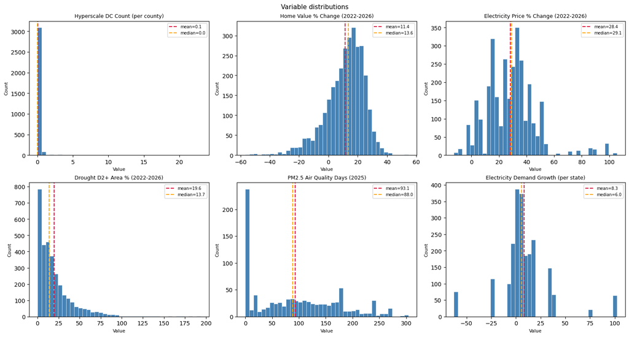

```python
dist_vars = [
    ("hyperscale_count",       "Hyperscale DC Count (per county)"),
    ("house_value_pct_change", "Home Value % Change (2022-2026)"),
    ("price_pct_change",       "Electricity Price % Change (2022-2026)"),
    ("drought_pct_d2plus",     "Drought D2+ Area % (2022-2026)"),
    ("days_pm25_2025",         "PM2.5 Air Quality Days (2025)"),
    ("demand_pct_change",      "Electricity Demand Growth (per state)"),
]

fig, axes = plt.subplots(2, 3, figsize=(15, 8), constrained_layout=True)
axes_flat = list(axes.flat)

for ax, (col, label) in zip(axes_flat, dist_vars):
    data = counties[col].dropna()
    ax.hist(data, bins=40, color="steelblue", edgecolor="white", linewidth=0.4)
    ax.axvline(data.mean(), color="crimson", linewidth=1.5, linestyle="--", label=f"mean={data.mean():.1f}")
    ax.axvline(data.median(), color="orange", linewidth=1.5, linestyle="--", label=f"median={data.median():.1f}")
    ax.set_title(label, fontsize=9)
    ax.set_xlabel("Value", fontsize=8)
    ax.set_ylabel("Count", fontsize=8)
    ax.legend(fontsize=7)

fig.suptitle("Variable distributions", fontsize=11)
os.makedirs("figures", exist_ok=True)
plt.savefig("figures/distributions.png", dpi=150, bbox_inches="tight")
plt.show()
```

#### Variable Choropleth Maps (Spatial Analysis)

**Number of Bins Choice and Classification Algorithm:**

All maps use Jenks, or natural breaks in order to show the natural changes in the data. Compared to quantiles, it offers more variations. All community impact variables have 5 bins in order to show the best amount of variation in geographical gradients.

**Hyper Scale Data Center Counts:** The bubble map shows hyperscale data center bubble map is heavily concentrated in a small number of metropolitan counties, consistent with the pre-cursor general data center analysis. This is also consistent with the summary statistic's 75th percentile. The Northern Virginia area, particularly Loudoun, Prince William, & Fairfax counties are part of the largest cluster and is clearly visible as the largest and brightest bubbles on the map. Secondary concentrations appear in Texas, the San Francisco Bay Area, and parts of the Midwest and Southeast, but none approach the scale of the Northern Virginia cluster.

**Home Value Appreciation % Change 2022 -> 2026:** The home value appreciation choropleth seems to cluster the highest around major metropolitan areas. Low-appreciation and negative-change counties are spread throughout the country. Comparing the areas of high hyperscale data center clusters, the home appreciations don't seem to have any relationship. The lack of a clear regional gradient in this map indicates that home value changes are driven by local market dynamics rather than any spatially structured process at the national scale.

**Residential Electricity Price % Change 2022 -> 2026:** The electricity price choropleth shows the most immediate visual alignment with the hyperscale data centers bubble map out of all the community impact variables. Loudoun falls into the highest price change bucket, having a percent change of 42.74%. A similar trend appears where high hyperscale data center counties fall into either the second highest or highest bucket. However, the discussion section reveals why the visual clustering and Moran's I score from the results vary.

**Drought D2+ Severity %:** The drought D2+ choropleth shows the clearest geographic pattern of all five variables, with severe drought concentrated in the western half of the country. Meanwhile, many parts of the eastern half do not seem to be in drought. However, this does not have any visual correlation to the hyperscale data center locations.

**PM2.5+ AQI Days:** The PM2.5 choropleth covers only 945 of 3,220 counties because the EPA only publishes annual AQI data for counties with active monitoring stations, introducing a geographic bias toward urban areas. The eastern half of the country shows much lower PM2.5 counts, which probably means scattered monitoring stations. There does not appear to be any visual correlations to hyperscale data center locations.

**Electricity Demand Growth % Change:** The electricity demand growth map is rendered at the state level because the EIA only reports demand data at the balancing authority resolution, as described in the methods section. However, in the states that contain the most data centers, such as Virginia or California, there is an increase in electricity demand. This still does not completely reflect the most accurate clustering due to the MAUP. States like Illinois which have a high concentration of data centers or states like Colorado that do not have any data centers in this dataset (It has recently gotten some) seem to in fact have an inverse relationship, where electricity demand is the opposite of the expected outcome. Since every county within a state inherits the same value, this map is more of a regional summary than an accurate measurement for spatial clustering. Thus, the implications for the spatial autocorrelation results are discussed in the discussion section.

```python
counties_simplified = counties.copy()
counties_simplified["geometry"] = counties_simplified.geometry.simplify(0.01, preserve_topology=True)
counties_geojson = json.loads(counties_simplified.to_json())

INSET_LEGEND = dict(
    x=0.985, y=0.02, xanchor="right", yanchor="bottom",
    bgcolor="rgba(255,255,255,0.88)",
    bordercolor="rgba(40,40,40,0.35)", borderwidth=1,
    font=dict(size=10),
)
INSET_COLORBAR = dict(
    x=0.985, y=0.02, xanchor="right", yanchor="bottom",
    len=0.45, thickness=14,
    bgcolor="rgba(255,255,255,0.88)",
    outlinecolor="rgba(40,40,40,0.35)", outlinewidth=1,
)

ctr = counties[["GEOID","NAME","STATEFP","hyperscale_count","hyperscale_density","geometry"]].copy()
ctr["geometry"] = ctr.geometry.centroid
ctr["lon"] = ctr.geometry.x
ctr["lat"] = ctr.geometry.y
bubbles = ctr[ctr["hyperscale_count"] > 0].copy()
bubbles["label"] = bubbles["NAME"] + " County (FIPS " + bubbles["STATEFP"] + ")"

fig = px.scatter_map(
    bubbles, lat="lat", lon="lon",
    size="hyperscale_count", color="hyperscale_count",
    color_continuous_scale="Plasma",
    size_max=42,
    zoom=MAP_ZOOM, center=MAP_CENTER,
    hover_name="label",
    hover_data={"hyperscale_count": True, "hyperscale_density": ":.4f", "lat": False, "lon": False},
    map_style=MAP_STYLE,
    title="<b>U.S. AI Data Centers per County</b><br><sup>Bubble size and color encode count of AI-focused facilities (Microsoft, Google, Amazon, Meta, Oracle, Apple, IBM, Applied Digital, Anthropic, xAI, CoreWeave, Crusoe, Nebius)</sup>",
    height=MAP_HEIGHT,
    labels={"hyperscale_count": "Hyperscale Data Centers"},
)
fig.update_traces(marker=dict(opacity=0.78, sizemin=3))
fig.update_layout(
    margin=dict(l=0, r=0, t=70, b=0),
    coloraxis_colorbar={**INSET_COLORBAR, "title": "Hyperscale DCs"},
)
show_map(fig)

vars_to_map = [
    ("house_value_pct_change",            "Home Value % Change Mar 2022 → Mar 2026",                     "Viridis", 1.0, "%", "Home value % change"),
    ("price_pct_change", "Residential Electricity Price % Change Feb 2022 → Feb 2026",  "YlGnBu", 1.0, "%", "Electricity price % change"),
    ("drought_pct_d2plus",         "Mean Drought D2+ Area % 2022–2026",                           "YlOrRd",   1.0, "%", "Drought D2+ area %"),
    ("days_pm25_2025",             "PM2.5 Air Quality Days (2025)",                               "BrBg",  1.0, "",  "PM2.5 days"),
]

N_BINS = 5

for col, title, cscale, factor, suffix, legend in vars_to_map:
    scaled_col = f"{col}_scaled"
    bin_col    = f"{col}_bin"
    counties_simplified[scaled_col] = counties_simplified[col] * factor

    valid = counties_simplified[scaled_col].dropna()
    jc = mapclassify.NaturalBreaks(valid, k=N_BINS)
    qs = np.concatenate([[valid.min()], jc.bins])
    qs[0]  -= 1e-9
    qs[-1] += 1e-9

    def fmt(v):
        return f"{v:.1f}{suffix}"

    bin_labels = [f"{fmt(qs[i])} – {fmt(qs[i+1])}" for i in range(N_BINS)]
    counties_simplified[bin_col] = pd.cut(
        counties_simplified[scaled_col], bins=qs, labels=bin_labels, include_lowest=True,
    ).astype("object")
    counties_simplified.loc[counties_simplified[scaled_col].isna(), bin_col] = "No data"

    palette_colors = px.colors.sample_colorscale(
        cscale, [i / (N_BINS - 1) for i in range(N_BINS)]
    )
    color_map = {lbl: clr for lbl, clr in zip(bin_labels, palette_colors)}
    color_map["No data"] = "#ececec"
    category_order = bin_labels + ["No data"]

    fig = px.choropleth_map(
        counties_simplified, geojson=counties_geojson,
        locations="GEOID", featureidkey="properties.GEOID",
        color=bin_col,
        color_discrete_map=color_map,
        category_orders={bin_col: category_order},
        map_style=MAP_STYLE, zoom=MAP_ZOOM, center=MAP_CENTER, opacity=0.85,
        hover_name="NAME",
        hover_data={bin_col: True, scaled_col: ":.2f", "hyperscale_count": True, "GEOID": False},
        labels={bin_col: legend, scaled_col: legend},
        title=f"<b>{title}</b>",
        height=MAP_HEIGHT,
    )
    fig.update_traces(marker_line_width=0.1, marker_line_color="white")
    fig.update_layout(
        margin=dict(l=0, r=0, t=60, b=0),
        legend={**INSET_LEGEND, "title": dict(text=legend, font=dict(size=11))},
    )
    show_map(fig)

state_demand = (
    counties.dropna(subset=["demand_pct_change"])
            .groupby("STATEFP")["demand_pct_change"]
            .first()
            .reset_index()
)
state_demand["demand_pct"] = state_demand["demand_pct_change"]

states_gdf_demand = state_borders.copy()
states_gdf_demand["STATEFP"] = states_gdf_demand["STATEFP"].astype(str).str.zfill(2)
states_gdf_demand = states_gdf_demand.merge(state_demand, on="STATEFP", how="left")
states_geojson_demand = json.loads(states_gdf_demand.to_json())

N_BINS_S = 5
sd = states_gdf_demand["demand_pct"].dropna()
jc = mapclassify.NaturalBreaks(sd, k=N_BINS_S)
qs = np.concatenate([[sd.min()], jc.bins])
qs[0]  -= 1e-9
qs[-1] += 1e-9
bin_labels = [f"{qs[i]:.1f}% – {qs[i+1]:.1f}%" for i in range(N_BINS_S)]
states_gdf_demand["demand_bin"] = pd.cut(
    states_gdf_demand["demand_pct"], bins=qs, labels=bin_labels, include_lowest=True,
).astype("object")
states_gdf_demand.loc[states_gdf_demand["demand_pct"].isna(), "demand_bin"] = "No data"

bupu_colors = px.colors.sample_colorscale("BuPu", [i / (N_BINS_S - 1) for i in range(N_BINS_S)])
demand_color_map = {lbl: clr for lbl, clr in zip(bin_labels, bupu_colors)}
demand_color_map["No data"] = "#ececec"
demand_category_order = bin_labels + ["No data"]

fig = px.choropleth_map(
    states_gdf_demand, geojson=states_geojson_demand,
    locations="STATEFP", featureidkey="properties.STATEFP",
    color="demand_bin",
    color_discrete_map=demand_color_map,
    category_orders={"demand_bin": demand_category_order},
    map_style=MAP_STYLE, zoom=MAP_ZOOM, center=MAP_CENTER, opacity=0.85,
    hover_name="NAME",
    hover_data={"demand_bin": True, "demand_pct": ":.2f", "STATEFP": False},
    labels={"demand_bin": "Electricity demand growth", "demand_pct": "Demand growth (%)"},
    title="<b>Electricity Demand Growth % Change, 2022 → 2026 (state level)</b>",
    height=MAP_HEIGHT,
)
fig.update_traces(marker_line_width=0.4, marker_line_color="white")
fig.update_layout(
    margin=dict(l=0, r=0, t=70, b=0),
    legend={**INSET_LEGEND, "title": dict(text="Electricity demand growth", font=dict(size=11))},
)
show_map(fig)
```

[output not shown]

### AI Use Disclosure

Claude Code (Anthropic 2025) is used throughout this project to assist with data cleaning, dynamic maps, spatial regressions, and debugging for other parts of code. All LLM-generated code was reviewed to match the textbook Geographic Thinking for Data Scientists (Rey et al 2025).

## Spatial Autocorrelation & Spatial Regression (Results)

#### Spatial weights matrix (K-Nearest-Neighbors, k=8)

The pre-cursor data analysis of general data centers used Queen contiguity weights and considered but rejected KNN. The reasoning there was that US county sizes vary vastly across the country, so KNN would force large rural western counties to have the same number of neighbors as small dense eastern counties, which felt like a poor match for the geography. Queen contiguity was preferred because it lets the data's natural polygon structure define the neighborhood.

That reasoning does not hold for this analysis. The variable of interest here is hyperscale data center density, which is concentrated in a small number of geographically dispersed major metros rather than spread continuously across the country. Queen contiguity is built around physical adjacency, so it can never connect two metro clusters that do not share a border, and large rural counties that separate them would simply absorb that disconnect. Queen contiguity also has a coastal boundary problem that became apparent in the pre-cursor analysis, where Miami-Dade County was not a LISA Hot spot, despite it having 47 data centers because coastal counties have fewer polygon neighbors than inland counties, giving them less statistical power in the weights calculation.

KNN with having 8 neighbors fixes both issues. Every county receives exactly 8 neighbors regardless of whether it sits on a coast or in the interior, removing the asymmetry that suppressed Miami-Dade in the pre-cursor analysis. It also allows major metros like Northern Virginia, the San Francisco Bay Area, and the Dallas-Fort Worth area to register as neighbors of one another through the nearest-neighbor graph, which better captures the spatial structure of a variable defined by a small number of dispersed clusters.

```python
counties = counties.reset_index(drop=True)
w = weights.distance.KNN.from_dataframe(counties, k=8)
w.transform = "R"

counties_simplified = counties.copy()
counties_simplified["geometry"] = counties_simplified.geometry.simplify(0.01, preserve_topology=True)
counties_geojson = json.loads(counties_simplified.to_json())
```

#### Bivariate Global Moran's I. DC density paired with each impact metric

Unlike univariate Moran's I, which would measure whether hyperscale data center density alone clusters in space (this test was done in the pre-cursor analysis for general data centers), the bivariate Moran's I tests done here measure the spatial clustering between hyperscale data center density and each community impact variable respectively. All five bivariate I values computed here fall very close to zero, ranging from -0.010 for drought to 0.046 for electricity demand growth. This indicates that at the national county scale, hyperscale data center density has practically no spatial co-clustering with any of the five community impact variables examined. This is partially consistent with the hypothesis. Drought and PM2.5 air quality days are not statistically significant (p = 0.118 and p = 0.215 respectively), supporting the expected absence of association for those variables. It is also expected due to those variables not having the full county counts. Home value appreciation (p = 0.022) and electricity price growth (p = 0.002) are statistically significant despite their near-zero I values, which reflects the large sample size of 3,220 counties. Electricity demand growth also has no clustering at I = 0.046 and is also significant (p = 0.001), which actually goes against the hypothesis of clustering. This is likely due to the state level aggregation, as well as the extent covering the entire country. The multivariate Moran's I among all the variables is also very low, which is expected due to the extent of the United States. It is still statistically significant (p =0.002).

```python
np.random.seed(123)

impact_vars_county = {
    "house_value_pct_change":                    "Home value % change",
    "price_pct_change":         "Residential electricity price % change",
    "drought_pct_d2plus":                 "Mean drought D2+ area %",
    "days_pm25_2025":                     "PM2.5 air quality days",
    "demand_pct_change":"Electricity demand growth",
}

bv_moran_results = {}
x_county = counties["hyperscale_density"].fillna(0).values
for var, label in impact_vars_county.items():
    y = counties[var].fillna(0).values
    bv_moran_results[var] = Moran_BV(x_county, y, w, permutations=999)
```

The univariate Moran's I for all data center density calculated in the pre-cursor analysis, was 0.19 (z = 22.07, p = 0.001). While 0.19 is still a weak value, it is still stronger than any of the five bivariate Moran's I values calculated here, which are all essentially zero. This contrast is important because data centers themselves do show some spatial clustering, but that clustering does not carry over into co-clustering with any of the community impact variables.

#### Bivariate and Multivariate Moran's I Scatterplots

Each scatterplot shows standardized hyperscale data center density on the x-axis against the spatial lag of the standardized impact variable on the y-axis. The spatial lag is the weighted average of a county's neighbors' values for the impact variable. The slope of the fitted line is the bivariate Moran's I value, so a steeper positive slope indicates stronger positive spatial co-clustering between the two variables.

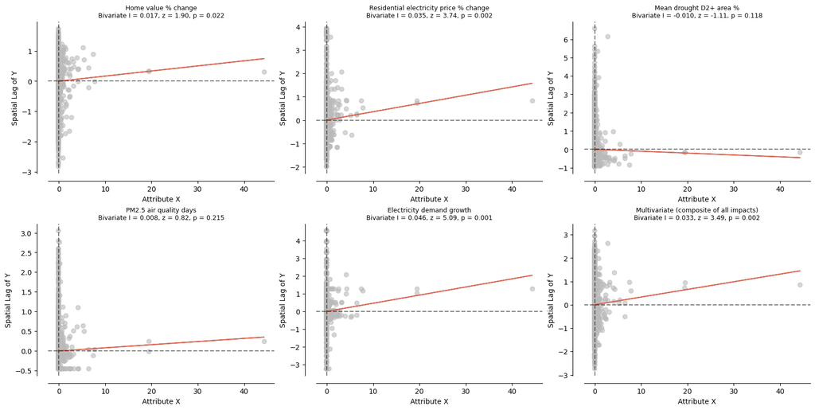

```python
impact_z = pd.DataFrame({
    var: (counties[var].fillna(counties[var].mean()) - counties[var].mean()) / counties[var].std(ddof=0)
    for var in impact_vars_county
})
composite_impact = impact_z.mean(axis=1).values
np.random.seed(123)
moran_multivariate = Moran_BV(
    counties["hyperscale_density"].fillna(0).values,
    composite_impact,
    w, permutations=999,
)

panels = list(impact_vars_county.items()) + [("__multivariate__", "Multivariate (composite of all impacts)")]
n_cols, n_rows = 3, 2
fig, axes = plt.subplots(n_rows, n_cols, figsize=(16, 8), constrained_layout=True)
axes = list(axes.flat)

for ax, (var, label) in zip(axes, panels):
    moran_obj = moran_multivariate if var == "__multivariate__" else bv_moran_results[var]
    moran_scatterplot(moran_obj, ax=ax, p=0.05)
    ax.set_aspect("auto")
    subtitle = f"Bivariate I = {moran_obj.I:.3f}, z = {moran_obj.z_sim:.2f}, p = {moran_obj.p_sim:.3f}"
    ax.set_title(label + "\n" + subtitle, fontsize=9)

for ax in axes[len(panels):]:
    ax.set_visible(False)

os.makedirs("figures", exist_ok=True)
plt.savefig("figures/moran_bv_scatterplots.png", dpi=150, bbox_inches="tight")
plt.show()
```

#### Bivariate LISA cluster maps- Hyperscale Data Center Density vs Community Impact Variables

**LISA Spot Finding Across Most Maps:**

In all LISA maps besides the air quality map, HH spots are surrounded by many LH spots and HL spots are surrounded by many LL spots. This is likely due to a county being one of the 8 neighbors, so from the neighbor's perspective, a low data center density that is situated next to a HH spot, making it LH.

**Home Value % Change:**

The home value appreciation LISA map has 33 High-High counties, scattered primarily across the midwest. Some of these counties, like Cook County, are where both hyperscale data center density and neighboring home value appreciation are simultaneously elevated. The dominant pattern however is Low-High, with 784 counties colored light blue, meaning counties with low data center density that are surrounded by high home value neighbors. This is the expected signature of urban housing markets that are appreciating for reasons unrelated to data center presence. Typically in univariate LISA maps, low-high and high-low spots are seen as outliers. The 652 Low-Low counties are in primarily rural areas.

**Residential Electricity Price % Change:**

The electricity price LISA map shows 34 High-High counties, with a notable cluster near the Northeast and Northern Virginia. The 801 Low-Low counties go through the Midwest. The 515 Low-High counties reflect regional grid pricing dynamics rather than a data center effect.

**Mean Drought D2+ Area %:**

The PM2.5 LISA map is the sparsest of all five, with only 11 High-High counties and no Low-Low counties at all. The absence of Low-Low counties reflects incomplete EPA monitoring coverage, with only 945 of 3,220 counties having data, so the sparseness reflects missing data rather than a true absence of spatial pattern. This can be similarly said about drought, although it still has more county coverage than this dataset.

**Electricity Demand Growth:**

The electricity demand LISA map shows 21 High-High counties, with the most visible cluster in Northern Virginia where hyperscale density is highest and the surrounding region falls into a high demand growth balancing authority. The map is otherwise dominated by state-boundary-aligned blocks of Low-Low and Low-High counties, reflecting the MAUP artifact discussed below. The HH clusters in electricity price and electricity demand both aligning with Northern Virginia suggests local co-clustering exists there even though it is averaged away in the global statistic.

```python
quadrant_to_label = {
    1: "High-High",
    2: "Low-High",
    3: "Low-Low",
    4: "High-Low",
}
short_labels = {0: "Not Significant", 1: "HH", 2: "LH", 3: "LL", 4: "HL"}
breakdown_order = ["HH", "LL", "HL", "LH", "Not Significant"]
cluster_colors = {
    "High-High":     "#d7191c",
    "Low-Low":      "#2c7bb6",
    "High-Low":     "#fdae61",
    "Low-High": "#abd9e9",
    "Not significant": "#ececec",
}
cluster_order = list(cluster_colors.keys())

np.random.seed(42)

x_county = counties["hyperscale_density"].fillna(0).values
for var, label in impact_vars_county.items():
    y = counties[var].fillna(0).values
    lisa = Moran_Local_BV(x_county, y, w, permutations=999)

    sig = lisa.p_sim <= 0.05
    spots = lisa.q * sig
    spot_series = pd.Series(spots).map(short_labels)
    counts = spot_series.value_counts().reindex(breakdown_order, fill_value=0).astype(int)
    breakdown_df = counts.to_frame(name="Counties").T
    breakdown_df.index = [f"Hyperscale DC density vs {label}"]
    print(f"LISA hotspot breakdown \u2014 Hyperscale DC density vs {label}")
    display(breakdown_df)

    col_q, col_p, col_l = f"bvlisa_q_{var}", f"bvlisa_p_{var}", f"bvlisa_label_{var}"
    counties_simplified[col_q] = lisa.q
    counties_simplified[col_p] = lisa.p_sim
    counties_simplified[col_l] = pd.Series(lisa.q).map(quadrant_to_label).values
    counties_simplified.loc[counties_simplified[col_p] > 0.05, col_l] = "Not significant"

    fig = px.choropleth_map(
        counties_simplified, geojson=counties_geojson,
        locations="GEOID", featureidkey="properties.GEOID",
        color=col_l,
        color_discrete_map=cluster_colors,
        category_orders={col_l: cluster_order},
        map_style=MAP_STYLE, zoom=MAP_ZOOM, center=MAP_CENTER, opacity=0.85,
        hover_name="NAME",
        hover_data={col_l: True, col_p: ":.3f", "hyperscale_count": True, "GEOID": False, col_q: False},
        labels={
            col_l: "Cluster type",
            col_p: "p-value",
            "hyperscale_count": "Hyperscale DCs",
        },
        title=f"<b>Bivariate LISA: Hyperscale DC density vs {label}</b><br><sup>Local Moran BV, KNN=8 weights, 999 permutations, p \u2264 0.05</sup>",
        height=MAP_HEIGHT,
    )
    fig.update_traces(marker_line_width=0.1, marker_line_color="white")
    fig.update_layout(
        margin=dict(l=0, r=0, t=60, b=0),
        legend={**INSET_LEGEND, "title": dict(text="Bivariate LISA", font=dict(size=11))},
    )
    show_map(fig)
```

```
LISA hotspot breakdown — Hyperscale DC density vs Home value % change
```

|  | HH | LL | HL | LH | Not Significant |
| --- | --- | --- | --- | --- | --- |
| Hyperscale DC density vs Home value % change | 33 | 652 | 24 | 784 | 1727 |

```
LISA hotspot breakdown — Hyperscale DC density vs Residential electricity price % change
```

|  | HH | LL | HL | LH | Not Significant |
| --- | --- | --- | --- | --- | --- |
| Hyperscale DC density vs Residential electricity price % change | 34 | 801 | 26 | 515 | 1844 |

```
LISA hotspot breakdown — Hyperscale DC density vs Mean drought D2+ area %
```

|  | HH | LL | HL | LH | Not Significant |
| --- | --- | --- | --- | --- | --- |
| Hyperscale DC density vs Mean drought D2+ area % | 20 | 1076 | 38 | 519 | 1567 |

```
LISA hotspot breakdown — Hyperscale DC density vs PM2.5 air quality days
```

|  | HH | LL | HL | LH | Not Significant |
| --- | --- | --- | --- | --- | --- |
| Hyperscale DC density vs PM2.5 air quality days | 11 | 0 | 18 | 298 | 2893 |

```
LISA hotspot breakdown — Hyperscale DC density vs Electricity demand growth
```

|  | HH | LL | HL | LH | Not Significant |
| --- | --- | --- | --- | --- | --- |
| Hyperscale DC density vs Electricity demand growth | 21 | 286 | 5 | 351 | 2557 |

#### Spatial regression. Effect estimation with state fixed effects

The Ordinary Least Squares (OLS) Regression model uses `spreg.OLS_Regimes` with state FIPS as the regime variable and `constant_regi="many"`, which gives each state its own intercept. This means that the model compares counties within the same state rather than across the entire country, controlling for anything that may differ between states, such as tax policy, energy regulation, and climate, that could make some states more likely to have both data centers and high impact values. The two predictors held constant across states are hyperscale data center count and log county population.

The OLS results show statistically significant hyperscale coefficients for three of the five outcomes: home value appreciation (coefficient -0.663, p = 0.020), residential electricity price growth (coefficient 0.664, p = 0.013), and drought stress (coefficient 1.223, p = 0.003). The directions are not all consistent with the community harm narrative. The negative home value coefficient suggests that within states, counties with more hyperscale data centers appreciated slightly less rather than more after controlling for population. PM2.5 air quality days and electricity demand growth are not significant. The electricity demand row shows a perfect R² = 1.000 and coefficients of essentially zero, which is the MAUP artifact described in the discussion section, since these are state fixed effects, the state aggregation makes all predictions a perfect fit. This is why spatial lag is necessary to produce more accurate predictions.

```python
counties["log_pop"] = np.log(counties["population"].replace(0, np.nan))

county_outcomes = {
    "house_value_pct_change":            "Home value % change (2022 to 2026)",
    "price_pct_change": "Residential electricity price % change (Feb 2022 to Feb 2026)",
    "drought_pct_d2plus":         "Mean drought D2+ area % (2022–2026)",
    "days_pm25_2025":             "PM2.5 air quality days (2025)",
    "demand_pct_change": "Electricity demand % change (Feb 2022 to Feb 2026)",
}
reg_predictors = ["hyperscale_count", "log_pop"]

ols_results = {}
ols_subs = {}
ols_rows = []
for outcome, label in county_outcomes.items():
    sub = counties.dropna(subset=[outcome] + reg_predictors + ["STATEFP"]).reset_index(drop=True)
    m = spreg.OLS_Regimes(
        sub[[outcome]].values,
        sub[reg_predictors].values,
        sub["STATEFP"].tolist(),
        constant_regi="many",
        cols2regi=[False] * len(reg_predictors),
        regime_err_sep=False,
        name_y=outcome,
        name_x=reg_predictors,
    )
    ols_results[outcome] = m
    ols_subs[outcome] = sub
    idx_hs = next(i for i, n in enumerate(m.name_x) if "hyperscale_count" in n)
    idx_lp = next(i for i, n in enumerate(m.name_x) if "log_pop" in n)
    ols_rows.append({
        "Outcome":                       label,
        "N counties":                    int(m.n),
        "R²":                            round(m.r2, 4),
        "Adjusted R²":                   round(m.ar2, 4),
        "Hyperscale DC coefficient":     round(m.betas.flatten()[idx_hs], 6),
        "Hyperscale DC std. error":      round(m.std_err.flatten()[idx_hs], 6),
        "Hyperscale DC p-value":         round(m.t_stat[idx_hs][1], 4),
        "Log population coefficient":    round(m.betas.flatten()[idx_lp], 6),
        "Log population p-value":        round(m.t_stat[idx_lp][1], 4),
    })

ols_table = pd.DataFrame(ols_rows).set_index("Outcome")
ols_table
```

| Outcome | N counties | R² | Adjusted R² | Hyperscale DC coefficient | Hyperscale DC std. error | Hyperscale DC p-value | Log population coefficient | Log population p-value |
| --- | --- | --- | --- | --- | --- | --- | --- | --- |
| Home value % change (2022 to 2026) | 3052 | 0.4299 | 0.4202 | -0.663128 | 0.284811 | 0.0200 | 1.544892 | 0.0000 |
| Residential electricity price % change (Feb 2022 to Feb 2026) | 3120 | 0.7195 | 0.7149 | 0.663564 | 0.267451 | 0.0132 | -0.129326 | 0.3410 |
| Mean drought D2+ area % (2022–2026) | 3211 | 0.5414 | 0.5339 | 1.222614 | 0.404446 | 0.0025 | -0.454183 | 0.0261 |
| PM2.5 air quality days (2025) | 937 | 0.2294 | 0.1859 | -2.013282 | 2.294808 | 0.3806 | 10.058716 | 0.0000 |
| Electricity demand % change (Feb 2022 to Feb 2026) | 2184 | 1.0000 | 1.0000 | -0.000000 | 0.000000 | 0.8132 | 0.000000 | 0.1228 |

#### Spatial lag and spatial error models

The spatial lag model (`spreg.GM_Lag`) accounts for the fact that neighboring counties often have similar outcomes. After adding spatial lag, none of the hyperscale data center coefficients remain statistically significant, with the previously significant OLS relationships weakening to p = 0.220 for home value, p = 0.458 for electricity price, and p = 0.149 for drought.

At the same time, the spatial lag coefficients are large and highly significant for electricity price (ρ = 1.036, p = 0.000), drought (ρ = 1.051, p = 0.000), and electricity demand (ρ = 1.000, p = 0.000). This indicates that neighboring counties explain much of the variation in these outcomes, suggesting that some significant OLS results were driven more by regional spatial clustering than by hyperscale data centers themselves. This suggests that hyperscale data centers are not the main reason for certain community impacts once spatial patterns are taken into account.

```python
import warnings, io, contextlib

reg_predictors = ["hyperscale_count", "log_pop"]
counties["log_pop"] = counties["log_pop"].fillna(counties["log_pop"].median())

gm_rows = []
gm_lag_results = {}

with warnings.catch_warnings(), contextlib.redirect_stdout(io.StringIO()), contextlib.redirect_stderr(io.StringIO()):
    warnings.simplefilter("ignore")

    for outcome, label in county_outcomes.items():
        mask = counties[outcome].notna()
        sub  = counties[mask].reset_index(drop=True)
        w_sub = weights.distance.KNN.from_dataframe(sub, k=8)
        w_sub.transform = "R"
        y = sub[[outcome]].values
        X = sub[reg_predictors].values

        m_lag = spreg.GM_Lag(y, X, w=w_sub, name_y=outcome, name_x=reg_predictors)
        gm_lag_results[outcome] = m_lag

        i_hs = m_lag.name_x.index("hyperscale_count")
        gm_rows.append({
            "Outcome":                   label,
            "N counties":                int(m_lag.n),
            "Pseudo R²":                 round(m_lag.pr2, 4),
            "Hyperscale DC coefficient": round(m_lag.betas.flatten()[i_hs], 6),
            "Hyperscale DC std. error":  round(m_lag.std_err.flatten()[i_hs], 6),
            "Hyperscale DC p-value":     round(m_lag.z_stat[i_hs][1], 4),
            "Spatial lag ρ (spillover)": round(m_lag.betas.flatten()[-1], 4),
            "Spatial lag ρ p-value":     round(m_lag.z_stat[-1][1], 4),
        })

gm_table = pd.DataFrame(gm_rows).set_index("Outcome")
gm_table
```

| Outcome | N counties | Pseudo R² | Hyperscale DC coefficient | Hyperscale DC std. error | Hyperscale DC p-value | Spatial lag ρ (spillover) | Spatial lag ρ p-value |
| --- | --- | --- | --- | --- | --- | --- | --- |
| Home value % change (2022 to 2026) | 3061 | 0.2095 | -0.429043 | 0.349733 | 0.2199 | 0.1018 | 0.6407 |
| Residential electricity price % change (Feb 2022 to Feb 2026) | 3129 | 0.8108 | 0.159127 | 0.214252 | 0.4577 | 1.0360 | 0.0000 |
| Mean drought D2+ area % (2022–2026) | 3211 | 0.9202 | 0.246014 | 0.170344 | 0.1487 | 1.0512 | 0.0000 |
| PM2.5 air quality days (2025) | 945 | 0.0666 | -2.187975 | 3.573948 | 0.5404 | -1.5051 | 0.3237 |
| Electricity demand % change (Feb 2022 to Feb 2026) | 2184 | 0.9279 | 0.243875 | 0.199188 | 0.2208 | 1.0003 | 0.0000 |

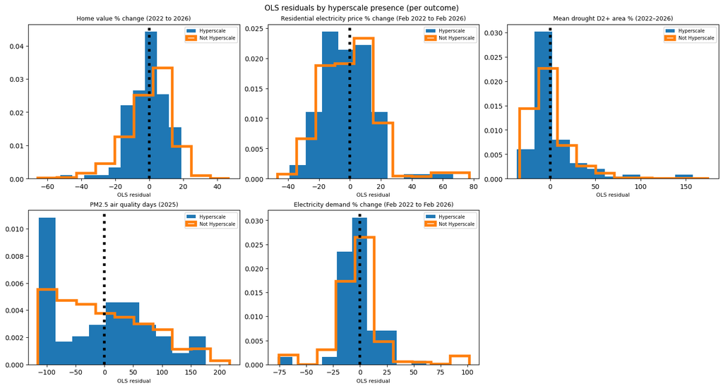

```python
ols_plain_results = {}
ols_plain_subs = {}
for outcome, label in county_outcomes.items():
    sub = counties.dropna(subset=[outcome] + reg_predictors).reset_index(drop=True)
    m = spreg.OLS(
        sub[[outcome]].values,
        sub[reg_predictors].values,
        name_y=outcome,
        name_x=reg_predictors,
    )
    ols_plain_results[outcome] = m
    ols_plain_subs[outcome] = sub

fig, axes = plt.subplots(2, 3, figsize=(15, 8), constrained_layout=True)
axes_flat = list(axes.flat)

for ax, (outcome, label) in zip(axes_flat, county_outcomes.items()):
    m = ols_plain_results[outcome]
    sub = ols_plain_subs[outcome].assign(residual=m.u.flatten())

    is_hyperscale = (sub["hyperscale_count"] > 0).values

    hyperscale = sub.loc[is_hyperscale, "residual"].values
    not_hyperscale = sub.loc[~is_hyperscale, "residual"].values

    ax.hist(hyperscale, density=True, label="Hyperscale")

    ax.hist(
        not_hyperscale,
        histtype="step",
        density=True,
        linewidth=4,
        label="Not Hyperscale",
    )

    ax.axvline(0, linestyle=":", color="k", linewidth=4)

    ax.legend(fontsize=7)
    ax.set_title(label, fontsize=9)
    ax.set_xlabel("OLS residual", fontsize=8)

for ax in axes_flat[len(county_outcomes):]:
    ax.set_visible(False)

fig.suptitle("OLS residuals by hyperscale presence (per outcome)", fontsize=11)

os.makedirs("figures", exist_ok=True)
plt.savefig("figures/regression_residuals_by_hyperscale.png", dpi=150, bbox_inches="tight")
plt.show()
```

## Discussion and Conclusion

Both hyperscale data center density and the five impact variables show visible geographic clustering in the choropleth maps, with density concentrated in Northern Virginia, Texas, California, Chicago metro areas. Community impact variables are elevated across urbanized areas. This visual overlap is misleading because data centers occupy a small area of the urban counties, and the two patterns do not track each other county by county. To truly understand correlations, examining the aforementioned counties at a census tract level would be the next level of analysis.

All five bivariate global Moran's I values are extremely close to zero, indicating no meaningful spatial co-clustering nationwide. The statistically significant p-values for home value appreciation, electricity price, and electricity demand reflect the scale of the United States' 3,220 counties.

While global clustering is non-existent, LISA maps reveal localized HH co-clustering in Northern Virginia, where data center density, electricity price growth, and electricity demand growth all concentrate simultaneously in the same counties. This local signal is the strongest evidence in the analysis that data center presence is associated with community impact, even as the global measure shows no nationwide pattern.

From analyzing spatial dependence to spatial heterogeneity, OLS regression finds significant coefficients for home value appreciation, electricity price growth, and drought stress within states, but once the spatial lag model accounts for neighboring county spillovers, none of the hyperscale coefficients remain significant. This confirms that regional spatial trends in neighboring counties, not data center presence itself, drive most of the outcome variation.

**Hypothesis Answer: Partially Supported.** The first part of the hypothesis holds true. Home value appreciation, drought stress, and PM2.5 air quality days all show near-zero bivariate global Moran's I values and no nationwide co-clustering with hyperscale data center density, consistent with the expectation of little association. Electricity price growth also has a near-zero global Moran's I but does show localized HH co-clustering in the Northern Virginia metro, which is a partial exception. However, the second part of the hypothesis is not supported. Electricity demand growth was expected to show a strong positive association and clustering, but the global bivariate I of 0.046 is only weakly positive, but even that value partly reflects the state-level aggregation of the underlying balancing authority data rather than a true county-scale clustering signal. The only real clustering for demand appears locally in Northern Virginia, which is where hyperscale density is highest, but this falls short of the strong nationwide pattern the hypothesis predicted. If the hypothesis were to be refined, it should include distinctions between global and local clustering. In this case, HH counties like Loudoun show local co-clustering between data center density, electricity price growth, and electricity demand growth respectively. In this case, the local LISA result is the more informative measure since the relevant clustering exists at a sub-national scale.

This Northern Virginia local co-clustering pattern is consistent with spatial heterogeneity rather than nationwide spatial dependence. This is because the near-zero global Moran's I values combined with a significant local HH cluster in Loudoun and Fairfax indicate the relationship exists in specific places rather than uniformly. The high significant spillover coefficients in the spatial lag model are a separate finding showing the outcome variables themselves are spatially autocorrelated across their neighbors, not driven by hyperscale data center density.

**Policy Implications.** The finding that community impacts are geographically concentrated rather than nationally distributed has direct relevance for how AI infrastructure development is governed. Co-clustering of hyperscale data center density with above-average electricity prices and demand is spatially confined to a small number of metropolitan counties. The burden of rapid AI infrastructure expansion therefore falls disproportionately on those communities rather than being diffused broadly across the country. Policy on a national scale may be insufficient to address these localized harms because residents of high-density data center counties face rising utility costs and constrained grid capacity that are largely invisible in aggregate statistics. This is likely why protests against AI data centers are more prevalent in local communities rather than across the entire United States. However, the lack of nationwide clustering should not be interpreted as a lack of harmful indicators but rather as evidence that harm is local to communities. These findings would be most beneficial to local communities' policy making decisions. However, from the pre-cursor analysis, data center related jobs were measured. In that, there seemed to be no local or global clustering, but the jobs did see a rapid increase in urban areas. This indicates that data centers do have some form of positive impact on a national level, while harms are seen in local areas. These are all important factors to consider when investing in where to build an AI data center.

**Data Limitation:** The electricity demand growth variable is measured at the balancing authority level and assigned uniformly to all counties within a state. Spatial autocorrelation results for this variable partly reflect state boundaries rather than true county-scale co-clustering, and the p-value of 0.001 would likely not be statistically significant if measured at true county scale. Additionally, the core data center dataset is not fully up-to-date and lacks an explicit "AI" column, so hyperscale data centers are used as the closest available.

**Next Steps:** Next steps would include linking sub-county data at the census tract level, where impacts on housing affordability and utility costs are more likely to be detectable given how localized these effects are. In an early version of the pre-cursor analysis, a census tract level analysis was done on Loudoun county, where the univariate global Moran's I value for data centers was approximately 0.25. While this is higher than any of the bivariate global Moran's I values, it is still weak. However, even within Loudoun county, most census tracts do not have a data center. Counterintuitively, Moran's I does not automatically rise as the spatial scale becomes more granular, and this is a part of the MAUP. This project identifies local problems, at a local scale, but fails to find meaningful correlations at a national scale. The next step is to analyze the local community problems, across many communities, and try to understand the underlying causes.

## References

All citations follow the Chicago Manual of Style, Notes-Bibliography format. Each dataset is cited at its original publisher, with a "Retrieved via" line where the data was obtained through a secondary distributor.

**counties.geojson** — county boundary polygons.

U.S. Census Bureau, Geography Division. 2024. *TIGER/Line Shapefiles: County and County Equivalent Entities, Lower 48 States, Alaska, Hawaii, Puerto Rico, and Outlying Areas.* Suitland, MD: U.S. Census Bureau. https://www.census.gov/geographies/mapping-files/time-series/geo/tiger-line-file.html.

Retrieved via: Frost, Simon D. W. 2018. "counties.geojson." GitHub Gist. https://gist.github.com/sdwfrost/d1c73f91dd9d175998ed166eb216994a.

**state_boundaries/tl_2025_us_state.shp** — state boundary polygons.

U.S. Census Bureau, Geography Division. 2025. *TIGER/Line Shapefiles 2025: States (and Equivalent).* Suitland, MD: U.S. Census Bureau. https://www2.census.gov/geo/tiger/TIGER2025/STATE/.

**datacenters.geojson** — point data of global data centers.

ATLAS (All The Locations of All Servers). 2024–2025. *Global Data Center Map: datacenters.geojson.* Compiled from operator disclosures, FERC and state regulatory filings, and trade-press reports.

Retrieved via: Global Data Center Map repository. https://github.com/Ringmast4r/Global-Data-Center-Map.

**ZHVI.csv** — Home Value Index Data

Zillow Group. 2026. *Zillow Home Value Index (ZHVI): Smoothed, Seasonally Adjusted, All Homes Time Series, County-Level Release, March 2026.* Seattle, WA: Zillow Research. https://www.zillow.com/research/data/.

**electricity_rates (GCS API)** — congressional-district utility rates.

U.S. Energy Information Administration. 2026. *Form EIA-861M: Monthly Electric Power Industry Report, Utility-Level Residential Rates.* Washington, DC: U.S. Department of Energy. https://www.eia.gov/electricity/data/eia861m/.

Retrieved via: Cloud Storage bucket `electricity_rates`, containing utility rate data embedded in CD119 congressional-district polygons. https://storage.googleapis.com/electricity_rates/cd_shapes/.

**county_population_2023.csv** — county population.

U.S. Census Bureau. 2024. *American Community Survey 5-Year Estimates, 2019–2023, Table B01003 (Total Population), County Level.* Washington, DC: U.S. Census Bureau. https://www.census.gov/programs-surveys/acs/.

**annual_aqi_by_county_2025.csv** — county PM2.5 air quality days.

U.S. Environmental Protection Agency, Office of Air Quality Planning and Standards. 2026. *Air Quality System (AQS) Pre-Generated Data Files: Annual AQI by County, 2025.* Research Triangle Park, NC: U.S. EPA. https://aqs.epa.gov/aqsweb/airdata/download_files.html.

**drought.csv** — county weekly drought severity.

National Drought Mitigation Center, U.S. Department of Agriculture, and National Oceanic and Atmospheric Administration. 2026. *U.S. Drought Monitor: Comprehensive Statistics, County Level, 2022–2026.* Lincoln, NE: University of Nebraska–Lincoln. https://droughtmonitor.unl.edu/DmData/DataDownload/ComprehensiveStatistics.aspx.

**EIA930_BALANCE_2022_Jan_Jun.csv**, **EIA930_BALANCE_2026_Jan_Jun.csv**, **EIA930_SUBREGION_2022_Jan_Jun.csv**, and **EIA930_SUBREGION_2026_Jan_Jun.csv** — balancing-authority demand.

U.S. Energy Information Administration. 2022. *Form EIA-930: Hourly and Daily Balancing Authority Operations Report — Six-Month Files (January–June 2022), BALANCE and SUBREGION.* Washington, DC: U.S. Department of Energy. https://www.eia.gov/electricity/gridmonitor/.

U.S. Energy Information Administration. 2026. *Form EIA-930: Hourly and Daily Balancing Authority Operations Report — Six-Month Files (January–June 2026), BALANCE and SUBREGION.* Washington, DC: U.S. Department of Energy. https://www.eia.gov/electricity/gridmonitor/.

**Geographic Data Science with Python** — Textbook.

Rey, Sergio J., Dani Arribas-Bel, and Levi J. Wolf. 2025. *Geographic Data Science with Python.* Boca Raton, FL: Chapman and Hall/CRC Press. https://geographicdata.science/book/.

**Claude Code** — LLM.

Anthropic. 2025. *Claude Code.* https://claude.ai/code.

In addition to previously mentioned Claude Code usages, Claude Code was also used to fact check writing and provide insight into result intepretations by analyzing cells and reading through raw data.